# BUDT 758X Project Report

# Next Tennis Championship!

## Group 6 (Deduct or Deuce): Siddhita Bagwe, Ronit Motiwale, Zilinmei Ye

## Introduction

Tennis is amongst the most popular sports around the world, with famous players such as Roger Federer, Rafael Nadal and Novak Djokovic who have brought about a decade of heat and interest in this particular sport.

When watching the game, we find that usually the commentator can quote a player’s historic and real-time performance easily, compare their career history, how they will perform in the ongoing season on the basis of their past encounters. Such comparisons must have a strong database to back up the claim, or even involve rather complex data analysis.

Sometimes, if the players are not familiar with each other, those statistics can be really helpful for them to develop countermeasures. For players themselves, studying that data can remind them what they should improve and whether they should change their strategy pattern at a certain point in the game. For common audiences like ourselves, that data is really a fun thing to look at and may help us to even predict who the winner will be.

Our project is mainly focusing on those ineresting prospects of the tennis games. By scraping data from the official ATP website((www.atptour.com), we try to compare the statistical standings of the players using different factors. We also try to build a regression model to estimate their atp scores, which is relevant to their rankings.

## Data source and Cleaning

We have 2 main data sources in our project:

A. official ATP website(www.atptour.com), there we scraped mainly three types of pages:

```
a. single ranking table (https://www.atptour.com/en/rankings/singles);

b. 100 individual player's link in the ranking table( e.g.https://www.atptour.com/en/players/novak-djokovic/d643/overview)

c. stats leaderboard for surve leaders and return leaders.

For these pages, we mainly scraped their tables using BeatifulSoup and selenium. We performed some basic cleaning such as convert types and deal with missing values.
```

B. Github resourse pages:

```
https://github.com/fivethirtyeight/data/tree/master/tennis-time;

https://github.com/JeffSackmann/tennis_atp.

https://codeload.github.com/JeffSackmann/tennis_atp/zip/master

There we use part of the dataset to explore other intereting prospect of the tennis field and indivisual player's performance.
```

## Part 1: Data Acquisition and Cleaning

```python
import requests
from bs4 import BeautifulSoup
import pandas as pd
import time
import numpy as np
from selenium import webdriver
from selenium.webdriver.firefox.options import Options
from selenium.webdriver.support.ui import WebDriverWait
from selenium.webdriver.support import expected_conditions as EC
from selenium.webdriver.common.by import By
from selenium.webdriver.chrome.options import Options
```

### 1. Scraping from the top100 ranking table

The ranking table containing basic data about each player from top 100 ATP rankings is available at https://www.atptour.com/en/rankings/singles (Links to an external site.)

```python
atp100single_listpage = requests.get('https://www.atptour.com/en/rankings/singles')
atp100single_listpage_soup = BeautifulSoup(atp100single_listpage.text, 'html.parser')
atp100single_list = atp100single_listpage_soup.find_all(name = 'tr')

# Creating a function to find player information
def dftakein(row):
    # find all column values in the original table that displayed in website
    row_content = atp100single_list[row]
    row_list = []
    s = row_content.find_all(name = 'td')
    # scrape url as a new column added in the original table
    for x in s:
        row_list.append(x.text.strip())
    row_list = row_list[:1] + row_list[3:]
    country = row_content.find(name = 'td', class_ = 'country-cell').find(name = 'img').get('alt')
    url = 'http://atptour.com' + row_content.find(name = 'td', class_ = 'player-cell').find(name = 'a').get('href')
    # insert url as the third column in the dataframe
    row_list.insert(2, url)
    row_list.insert(3, country)
    return pd.DataFrame(row_list).T

# Generate the table and add column names
df_top100 = pd.DataFrame()
for index in range(1,len(atp100single_list)):
    df_top100 = df_top100.append(dftakein(index))
df_top100.columns = ['Ranking', 'Player Name','Player link','Country',
                     'Age','Points','Tourn Played','Points Dropping','Next Best']
df_top100 =  df_top100.reset_index(drop = True)
df_top100
```

|  | Ranking | Player Name | Player link | Country | Age | Points | Tourn Played | Points Dropping | Next Best |
| --- | --- | --- | --- | --- | --- | --- | --- | --- | --- |
| 0 | 1 | Rafael Nadal | http://atptour.com/en/players/rafael-nadal/n40... | ESP | 33 | 9,985 | 17 | 0 | 0 |
| 1 | 2 | Novak Djokovic | http://atptour.com/en/players/novak-djokovic/d... | SRB | 32 | 9,145 | 17 | 0 | 0 |
| 2 | 3 | Roger Federer | http://atptour.com/en/players/roger-federer/f3... | SUI | 38 | 6,590 | 17 | 0 | 0 |
| 3 | 4 | Dominic Thiem | http://atptour.com/en/players/dominic-thiem/tb... | AUT | 26 | 5,825 | 22 | 0 | 0 |
| 4 | 5 | Daniil Medvedev | http://atptour.com/en/players/daniil-medvedev/... | RUS | 23 | 5,705 | 24 | 0 | 0 |
| ... | ... | ... | ... | ... | ... | ... | ... | ... | ... |
| 95 | 96 | Salvatore Caruso | http://atptour.com/en/players/salvatore-caruso... | ITA | 26 | 586 | 28 | 0 | 0 |
| 96 | 97 | Alexei Popyrin | http://atptour.com/en/players/alexei-popyrin/p... | AUS | 20 | 585 | 25 | 0 | 0 |
| 97 | 98 | Egor Gerasimov | http://atptour.com/en/players/egor-gerasimov/g... | BLR | 27 | 581 | 23 | 0 | 0 |
| 98 | 99 | Lloyd Harris | http://atptour.com/en/players/lloyd-harris/hg8... | RSA | 22 | 576 | 24 | 0 | 0 |
| 99 | 100 | James Duckworth | http://atptour.com/en/players/james-duckworth/... | AUS | 27 | 576 | 28 | 0 | 0 |

100 rows × 9 columns

### 2. Scraping individual player's link

```python
indv_info_list = []
for index in list(range(100)):
    indv_page = requests.get(df_top100['Player link'][index])
    indv_page_soup = BeautifulSoup(indv_page.text, 'html.parser')
    indv_list = indv_page_soup.find_all(name = 'div', class_='wrap')
    playerstatraw = []
    for value in indv_list:
        playerstatraw.append(value.text.strip())
        rowlist = []
        for row in playerstatraw:
            if row in playerstatraw[:4]:
                row = row.strip().split()[-1]
            else:
                row = row.strip().split()[1:]
                row = ' '.join(row)
            rowlist.append(row)
    time.sleep(0.05)
    indv_info_list.append(rowlist)
    continue
df_indv = pd.DataFrame(indv_info_list)
df_indv.columns = ['BirthDate', 'Turned Pro','Weight','Height','Birthplace', 'Residence','Plays', 'Coach']
df_indv
```

|  | BirthDate | Turned Pro | Weight | Height | Birthplace | Residence | Plays | Coach |
| --- | --- | --- | --- | --- | --- | --- | --- | --- |
| 0 | (1986.06.03) | 2001 | 187lbs(85kg) | 6'1"(185cm) | Manacor, Mallorca, Spain | Manacor, Mallorca, Spain | Left-Handed, Two-Handed Backhand | Carlos Moya, Francisco Roig |
| 1 | (1987.05.22) | 2003 | 170lbs(77kg) | 6'2"(188cm) | Belgrade, Serbia | Monte Carlo, Monaco | Right-Handed, Two-Handed Backhand | Marian Vajda, Goran Ivanisevic |
| 2 | (1981.08.08) | 1998 | 187lbs(85kg) | 6'1"(185cm) | Basel, Switzerland | Switzerland | Right-Handed, One-Handed Backhand | Ivan Ljubicic, Severin Luthi |
| 3 | (1993.09.03) | 2011 | 174lbs(79kg) | 6'1"(185cm) | Wiener Neustadt, Austria | Lichtenworth, Austria | Right-Handed, One-Handed Backhand | Nicolas Massu |
| 4 | (1996.02.11) | 2014 | 182lbs(83kg) | 6'6"(198cm) | Moscow, Russia | Monte Carlo, Monaco | Right-Handed, Two-Handed Backhand | Gilles Cervara |
| ... | ... | ... | ... | ... | ... | ... | ... | ... |
| 95 | (1992.12.15) | 2010 | 176lbs(80kg) | 6'1"(185cm) | Avola, Italy | Avola, Italy | Right-Handed, Two-Handed Backhand | Paolo Cannova |
| 96 | (1999.08.05) | 2017 | 172lbs(78kg) | 6'5"(196cm) | Sydney, Australia | Sydney, Australia | Right-Handed, Two-Handed Backhand | Philipp Wagner |
| 97 | (1992.11.11) | 2010 | 190lbs(86kg) | 6'5"(196cm) | Minsk, Belarus | Minsk, Belarus | Right-Handed, Two-Handed Backhand | Arturs Kazijevs |
| 98 | (1997.02.24) | 2015 | 176lbs(80kg) | 6'4"(193cm) | Cape Town, South Africa | Cape Town, South Africa | Right-Handed, Two-Handed Backhand | Anthony Harris |
| 99 | (1992.01.21) | 2010 | 181lbs(82kg) | 6'0"(183cm) | Sydney, Australia | Sydney, Australia | Right-Handed, Two-Handed Backhand | Mark Draper |

100 rows × 8 columns

```python
df_top100 = df_top100.join(df_indv)
# data cleaning
df_top100 = df_top100.set_index('Ranking')
df_top100['Points'] = df_top100['Points'].str.replace(',', '')
ch = ['Age', 'Points','Tourn Played','Points Dropping','Next Best','Turned Pro']
for x in ch:
    df_top100[x] = df_top100[x].astype(int)
df_top100
```

| Ranking | Player Name | Player link | Country | Age | Points | Tourn Played | Points Dropping | Next Best | BirthDate | Turned Pro | Weight | Height | Birthplace | Residence | Plays | Coach |
| --- | --- | --- | --- | --- | --- | --- | --- | --- | --- | --- | --- | --- | --- | --- | --- | --- |
| 1 | Rafael Nadal | http://atptour.com/en/players/rafael-nadal/n40... | ESP | 33 | 9985 | 17 | 0 | 0 | (1986.06.03) | 2001 | 187lbs(85kg) | 6'1"(185cm) | Manacor, Mallorca, Spain | Manacor, Mallorca, Spain | Left-Handed, Two-Handed Backhand | Carlos Moya, Francisco Roig |
| 2 | Novak Djokovic | http://atptour.com/en/players/novak-djokovic/d... | SRB | 32 | 9145 | 17 | 0 | 0 | (1987.05.22) | 2003 | 170lbs(77kg) | 6'2"(188cm) | Belgrade, Serbia | Monte Carlo, Monaco | Right-Handed, Two-Handed Backhand | Marian Vajda, Goran Ivanisevic |
| 3 | Roger Federer | http://atptour.com/en/players/roger-federer/f3... | SUI | 38 | 6590 | 17 | 0 | 0 | (1981.08.08) | 1998 | 187lbs(85kg) | 6'1"(185cm) | Basel, Switzerland | Switzerland | Right-Handed, One-Handed Backhand | Ivan Ljubicic, Severin Luthi |
| 4 | Dominic Thiem | http://atptour.com/en/players/dominic-thiem/tb... | AUT | 26 | 5825 | 22 | 0 | 0 | (1993.09.03) | 2011 | 174lbs(79kg) | 6'1"(185cm) | Wiener Neustadt, Austria | Lichtenworth, Austria | Right-Handed, One-Handed Backhand | Nicolas Massu |
| 5 | Daniil Medvedev | http://atptour.com/en/players/daniil-medvedev/... | RUS | 23 | 5705 | 24 | 0 | 0 | (1996.02.11) | 2014 | 182lbs(83kg) | 6'6"(198cm) | Moscow, Russia | Monte Carlo, Monaco | Right-Handed, Two-Handed Backhand | Gilles Cervara |
| ... | ... | ... | ... | ... | ... | ... | ... | ... | ... | ... | ... | ... | ... | ... | ... | ... |
| 96 | Salvatore Caruso | http://atptour.com/en/players/salvatore-caruso... | ITA | 26 | 586 | 28 | 0 | 0 | (1992.12.15) | 2010 | 176lbs(80kg) | 6'1"(185cm) | Avola, Italy | Avola, Italy | Right-Handed, Two-Handed Backhand | Paolo Cannova |
| 97 | Alexei Popyrin | http://atptour.com/en/players/alexei-popyrin/p... | AUS | 20 | 585 | 25 | 0 | 0 | (1999.08.05) | 2017 | 172lbs(78kg) | 6'5"(196cm) | Sydney, Australia | Sydney, Australia | Right-Handed, Two-Handed Backhand | Philipp Wagner |
| 98 | Egor Gerasimov | http://atptour.com/en/players/egor-gerasimov/g... | BLR | 27 | 581 | 23 | 0 | 0 | (1992.11.11) | 2010 | 190lbs(86kg) | 6'5"(196cm) | Minsk, Belarus | Minsk, Belarus | Right-Handed, Two-Handed Backhand | Arturs Kazijevs |
| 99 | Lloyd Harris | http://atptour.com/en/players/lloyd-harris/hg8... | RSA | 22 | 576 | 24 | 0 | 0 | (1997.02.24) | 2015 | 176lbs(80kg) | 6'4"(193cm) | Cape Town, South Africa | Cape Town, South Africa | Right-Handed, Two-Handed Backhand | Anthony Harris |
| 100 | James Duckworth | http://atptour.com/en/players/james-duckworth/... | AUS | 27 | 576 | 28 | 0 | 0 | (1992.01.21) | 2010 | 181lbs(82kg) | 6'0"(183cm) | Sydney, Australia | Sydney, Australia | Right-Handed, Two-Handed Backhand | Mark Draper |

100 rows × 16 columns

### 3. Scraping service leaderboards

```python
options = Options()
browser = webdriver.Chrome(options=options)
service_url = "https://www.atptour.com/en/stats/leaderboard?boardType=serve&timeFrame=Career&surface=all&versusRank=all&formerNo1=false"
browser.get(service_url)
soup = BeautifulSoup(browser.page_source, 'html.parser')
```

```python
Names_s=[]
a=soup.find_all(name='a', class_="stats-player-name")
for i in a:
    Names_s.append(i.text)

serveRating=[]
ba=soup.find_all(attrs={"data-type":"serveRating"})
for i in ba:
    serveRating.append(i.text)

_1stServePct=[]
ba1=soup.find_all(attrs={"data-type":"1stServePct"})
for i in ba1:
    _1stServePct.append(i.text)

_1stServePointsWonPct=[]
ba2 =soup.find_all(attrs={"data-type":"1stServePointsWonPct"})
for i in ba2:
    _1stServePointsWonPct.append(i.text)

_2ndServePointsWonPct=[]
ba3 =soup.find_all(attrs={"data-type":"2ndServePointsWonPct"})
for i in ba3:
    _2ndServePointsWonPct.append(i.text)

serviceGamesWonPct=[]
ba4 =soup.find_all(attrs={"data-type":"serviceGamesWonPct"})
for i in ba4:
    serviceGamesWonPct.append(i.text)

avgAcesPerMatch=[]
ba5 =soup.find_all(attrs={"data-type":"avgAcesPerMatch"})
for i in ba5:
    avgAcesPerMatch.append(i.text)

avgDblFaultsPerMatch=[]
ba6 =soup.find_all(attrs={"data-type":"avgDblFaultsPerMatch"})
for i in ba6:
    avgDblFaultsPerMatch.append(i.text)
```

```python
atp_serve = pd.DataFrame(np.column_stack([Names_s, serveRating, _1stServePct, _1stServePointsWonPct, _2ndServePointsWonPct, serviceGamesWonPct,avgAcesPerMatch, avgDblFaultsPerMatch ]),
                               columns=['Player','serveRating', '1stServePct', '1stServePointsWonPct','2ndServePointsWonPct','serviceGamesWonPct','avgAcesPerMatch','avgDblFaultsPerMatch'])
con = atp_serve.columns[1:].to_list()
for x in con:
    atp_serve[x] = atp_serve[x].str.rstrip("%")
    atp_serve[x] = atp_serve[x].astype(float)
atp_serve
```

|  | Player | serveRating | 1stServePct | 1stServePointsWonPct | 2ndServePointsWonPct | serviceGamesWonPct | avgAcesPerMatch | avgDblFaultsPerMatch |
| --- | --- | --- | --- | --- | --- | --- | --- | --- |
| 0 | John Isner | 311.6 | 69.1 | 78.6 | 56.2 | 91.8 | 18.1 | 2.2 |
| 1 | Ivo Karlovic | 310.0 | 65.5 | 82.8 | 53.3 | 92.1 | 19.8 | 3.5 |
| 2 | Reilly Opelka | 303.0 | 62.0 | 79.7 | 55.2 | 90.4 | 19.3 | 3.6 |
| 3 | Milos Raonic | 302.5 | 62.9 | 81.4 | 55.0 | 91.0 | 15.4 | 3.2 |
| 4 | Andy Roddick | 299.9 | 64.8 | 79.3 | 56.0 | 90.1 | 11.7 | 2.0 |
| ... | ... | ... | ... | ... | ... | ... | ... | ... |
| 694 | Razvan Sabau | 226.2 | 59.3 | 62.0 | 44.5 | 62.1 | 2.4 | 4.1 |
| 695 | Marian Vajda | 223.4 | 54.3 | 61.5 | 47.6 | 61.7 | 2.3 | 4.0 |
| 696 | Daniel Elsner | 222.4 | 54.1 | 63.5 | 44.9 | 61.8 | 2.7 | 4.6 |
| 697 | Bart Wuyts | 221.6 | 70.1 | 57.7 | 40.9 | 56.7 | 0.4 | 4.2 |
| 698 | Kris Goossens | 217.6 | 52.5 | 65.5 | 40.9 | 60.9 | 3.1 | 5.3 |

699 rows × 8 columns

### 4. Scraping return leaderboards

```python
options = Options()
browser = webdriver.Chrome(options=options)
return_url = "https://www.atptour.com/en/stats/leaderboard?boardType=return&timeFrame=Career&surface=all&versusRank=all&formerNo1=false"
browser.get(return_url)
soup_return=BeautifulSoup(browser.page_source, 'html.parser')
```

```python
Names_r=[]
rt = soup_return.find_all(name='a', class_="stats-player-name")
for i in rt:
    Names_r.append(i.text)

returnRating=[]
ba_rt =soup_return.find_all(attrs={"data-type":"returnRating"})
for i in ba_rt:
    returnRating.append(i.text)

_1stServeReturnPointsWonPct=[]
ba_1st =soup_return.find_all(attrs={"data-type":"1stServeReturnPointsWonPct"})
for i in ba_1st:
    _1stServeReturnPointsWonPct.append(i.text)

_2ndServeReturnPointsWonPct=[]
ba_2nd =soup_return.find_all(attrs={"data-type":"2ndServeReturnPointsWonPct"})
for i in ba_2nd:
    _2ndServeReturnPointsWonPct.append(i.text)

returnGamesWonPct=[]
ba_re =soup_return.find_all(attrs={"data-type":"returnGamesWonPct"})
for i in ba_re:
    returnGamesWonPct.append(i.text)

brkPointsConvertedPct=[]
ba_con =soup_return.find_all(attrs={"data-type":"brkPointsConvertedPct"})
for i in ba_con:
    brkPointsConvertedPct.append(i.text)
```

```python
atp_return = pd.DataFrame(np.column_stack([Names_r, returnRating, _1stServeReturnPointsWonPct, _2ndServeReturnPointsWonPct, returnGamesWonPct,brkPointsConvertedPct ]),columns=
                          ['Player','returnRating', '1stServeReturnPointsWonPct','2ndServeReturnPointsWonPct','returnGamesWonPct','brkPointsConvertedPct'])
# data cleaning
lst = atp_return.columns[1:].to_list()
for x in lst:
    atp_return[x] = atp_return[x].str.rstrip("%")
    atp_return[x] = atp_return[x].astype(float)
atp_return
```

|  | Player | returnRating | 1stServeReturnPointsWonPct | 2ndServeReturnPointsWonPct | returnGamesWonPct | brkPointsConvertedPct |
| --- | --- | --- | --- | --- | --- | --- |
| 0 | Guillermo Coria | 171.5 | 36.1 | 54.4 | 35.3 | 45.7 |
| 1 | Guillermo Perez-Roldan | 168.1 | 35.8 | 53.2 | 32.5 | 46.6 |
| 2 | Rafael Nadal | 167.9 | 34.2 | 55.3 | 33.5 | 44.9 |
| 3 | Alberto Berasategui | 166.4 | 33.5 | 56.2 | 32.3 | 44.4 |
| 4 | Franco Davin | 166.3 | 34.8 | 53.2 | 32.8 | 45.5 |
| ... | ... | ... | ... | ... | ... | ... |
| 694 | John Isner | 105.5 | 22.6 | 41.9 | 10.5 | 30.5 |
| 695 | Wayne Arthurs | 103.9 | 23.4 | 40.5 | 10.0 | 30.0 |
| 696 | Ivo Karlovic | 100.3 | 21.3 | 40.2 | 8.6 | 30.2 |
| 697 | Reilly Opelka | 98.6 | 20.2 | 41.8 | 9.3 | 27.3 |
| 698 | Chris Guccione | 98.5 | 21.4 | 40.3 | 8.6 | 28.2 |

699 rows × 6 columns

### 5. Merging dataframes

Need to consider what to do with missing values.... Because 14 players in top 100 ranking still do not have data in Service table.

```python
df_new = pd.merge(df_top100.reset_index(), atp_serve, left_on= 'Player Name', right_on='Player',sort=False)
dftop100 = pd.merge(df_new, atp_return, left_on= 'Player Name', right_on='Player',sort=False)
dftop100 = dftop100.drop(['Player_x','Player_y'], axis=1)
dftop100.index += 1
dftop100_86 = dftop100
dftop100_86
```

|  | Ranking | Player Name | Player link | Country | Age | Points | Tourn Played | Points Dropping | Next Best | BirthDate | ... | 1stServePointsWonPct | 2ndServePointsWonPct | serviceGamesWonPct | avgAcesPerMatch | avgDblFaultsPerMatch | returnRating | 1stServeReturnPointsWonPct | 2ndServeReturnPointsWonPct | returnGamesWonPct | brkPointsConvertedPct |
| --- | --- | --- | --- | --- | --- | --- | --- | --- | --- | --- | --- | --- | --- | --- | --- | --- | --- | --- | --- | --- | --- |
| 1 | 1 | Rafael Nadal | http://atptour.com/en/players/rafael-nadal/n40... | ESP | 33 | 9985 | 17 | 0 | 0 | (1986.06.03) | ... | 72.0 | 57.4 | 85.8 | 3.0 | 1.6 | 167.9 | 34.2 | 55.3 | 33.5 | 44.9 |
| 2 | 2 | Novak Djokovic | http://atptour.com/en/players/novak-djokovic/d... | SRB | 32 | 9145 | 17 | 0 | 0 | (1987.05.22) | ... | 73.5 | 55.6 | 85.7 | 5.4 | 2.3 | 165.0 | 33.6 | 55.0 | 32.0 | 44.4 |
| 3 | 3 | Roger Federer | http://atptour.com/en/players/roger-federer/f3... | SUI | 38 | 6590 | 17 | 0 | 0 | (1981.08.08) | ... | 77.4 | 56.9 | 88.8 | 7.8 | 1.9 | 151.5 | 32.6 | 51.0 | 26.7 | 41.2 |
| 4 | 4 | Dominic Thiem | http://atptour.com/en/players/dominic-thiem/tb... | AUT | 26 | 5825 | 22 | 0 | 0 | (1993.09.03) | ... | 74.1 | 53.3 | 82.9 | 5.8 | 2.8 | 141.8 | 29.9 | 50.0 | 23.2 | 38.7 |
| 5 | 5 | Daniil Medvedev | http://atptour.com/en/players/daniil-medvedev/... | RUS | 23 | 5705 | 24 | 0 | 0 | (1996.02.11) | ... | 73.7 | 51.7 | 81.2 | 7.6 | 3.5 | 146.6 | 29.3 | 52.5 | 24.6 | 40.2 |
| ... | ... | ... | ... | ... | ... | ... | ... | ... | ... | ... | ... | ... | ... | ... | ... | ... | ... | ... | ... | ... | ... |
| 82 | 92 | Leonardo Mayer | http://atptour.com/en/players/leonardo-mayer/m... | ARG | 32 | 603 | 23 | 0 | 0 | (1987.05.15) | ... | 73.4 | 52.5 | 81.8 | 6.3 | 3.5 | 129.3 | 27.0 | 48.0 | 17.6 | 36.7 |
| 83 | 93 | Damir Dzumhur | http://atptour.com/en/players/damir-dzumhur/d9... | BIH | 27 | 594 | 29 | 0 | 0 | (1992.05.20) | ... | 65.1 | 49.6 | 70.9 | 2.6 | 2.8 | 152.6 | 31.7 | 50.7 | 26.9 | 43.3 |
| 84 | 95 | Ivo Karlovic | http://atptour.com/en/players/ivo-karlovic/k33... | CRO | 40 | 586 | 21 | 0 | 0 | (1979.02.28) | ... | 82.8 | 53.3 | 92.1 | 19.8 | 3.5 | 100.3 | 21.3 | 40.2 | 8.6 | 30.2 |
| 85 | 97 | Alexei Popyrin | http://atptour.com/en/players/alexei-popyrin/p... | AUS | 20 | 585 | 25 | 0 | 0 | (1999.08.05) | ... | 73.2 | 49.6 | 79.5 | 8.5 | 4.3 | 114.2 | 24.6 | 42.5 | 13.9 | 33.2 |
| 86 | 100 | James Duckworth | http://atptour.com/en/players/james-duckworth/... | AUS | 27 | 576 | 28 | 0 | 0 | (1992.01.21) | ... | 72.6 | 49.4 | 78.1 | 10.0 | 3.9 | 120.4 | 24.6 | 45.4 | 14.3 | 36.1 |

86 rows × 29 columns

## Part 2: Data Visualization

```python
from geopy.geocoders import Nominatim
import plotly.graph_objects as go
import matplotlib.pyplot as plt
from math import pi
import seaborn as sns
```

### 1. Birthplace

Which area resembles the best players?

```python
df_birth = df_top100[['Player Name','Birthplace']].reset_index()
geolocator = Nominatim(user_agent="specify_your_app_name_here")
latitude,longitude= [],[]
for place in df_birth['Birthplace']:
    location = geolocator.geocode(place)
    latitude.append(location.latitude)
    longitude.append(location.longitude)
df_birth['Latitude'] = pd.Series(latitude)
df_birth['Longitude'] = pd.Series(longitude)
df_birth.head()
```

|  | Ranking | Player Name | Birthplace | Latitude | Longitude |
| --- | --- | --- | --- | --- | --- |
| 0 | 1 | Rafael Nadal | Manacor, Mallorca, Spain | 39.571309 | 2.657654 |
| 1 | 2 | Novak Djokovic | Belgrade, Serbia | 44.817813 | 20.456897 |
| 2 | 3 | Roger Federer | Basel, Switzerland | 47.558108 | 7.587826 |
| 3 | 4 | Dominic Thiem | Wiener Neustadt, Austria | 47.808701 | 16.236973 |
| 4 | 5 | Daniil Medvedev | Moscow, Russia | 55.750446 | 37.617494 |

```python
mapbox_access_token = 'pk.eyJ1IjoiYWxpY2lheWUwNyIsImEiOiJjazJvOWN4emcwOTRuM21zeHJzMmZ4YzN5In0.K9QTCy7YYr-f7ZpQG6shjw'
birthplace_map_data = go.Scattermapbox(
        lon = df_birth['Longitude'],
        lat = df_birth['Latitude'],
        text = df_birth['Player Name'] + '<br>' + df_birth['Ranking'],
        hoverinfo='text',
        mode = 'markers',
        marker = dict(
                    color = 'green',
                    symbol = 'circle',
                    opacity = .5
                )
)

birthplace_map_layout = go.Layout(
        title = 'Birthplace of top 100 Players',
        mapbox=go.layout.Mapbox(
            accesstoken=mapbox_access_token,
            zoom=1
        )
    )

birthplace_map = go.Figure(data = birthplace_map_data, layout = birthplace_map_layout)
birthplace_map.show()
```

[interactive chart not shown]

#### Conlusion: From the graph, we can see that the most of the top 100 players' Birthplace is in Europe.

### 2. Career Duration & Age

##### How long does it take for a player to turn pro? Since what age they begin playing to become a master of the game?

```python
df_career = df_top100[['Player Name','Age','Turned Pro']].reset_index()
df_career['Career Duration'] = 2020 - df_career['Turned Pro']
df_career['Turned Pro Age'] = df_career['Age'] - df_career['Career Duration']
df_career.describe()
```

|  | Age | Turned Pro | Career Duration | Turned Pro Age |
| --- | --- | --- | --- | --- |
| count | 100.000000 | 100.000000 | 100.000000 | 100.000000 |
| mean | 27.120000 | 2009.700000 | 10.300000 | 16.820000 |
| std | 4.911911 | 5.022173 | 5.022173 | 1.424036 |
| min | 18.000000 | 1997.000000 | 1.000000 | 14.000000 |
| 25% | 23.000000 | 2006.750000 | 6.000000 | 16.000000 |
| 50% | 27.000000 | 2010.000000 | 10.000000 | 17.000000 |
| 75% | 31.000000 | 2014.000000 | 13.250000 | 17.000000 |
| max | 40.000000 | 2019.000000 | 23.000000 | 21.000000 |

```python
df_career.head()
```

|  | Ranking | Player Name | Age | Turned Pro | Career Duration | Turned Pro Age |
| --- | --- | --- | --- | --- | --- | --- |
| 0 | 1 | Rafael Nadal | 33 | 2001 | 19 | 14 |
| 1 | 2 | Novak Djokovic | 32 | 2003 | 17 | 15 |
| 2 | 3 | Roger Federer | 38 | 1998 | 22 | 16 |
| 3 | 4 | Dominic Thiem | 26 | 2011 | 9 | 17 |
| 4 | 5 | Daniil Medvedev | 23 | 2014 | 6 | 17 |

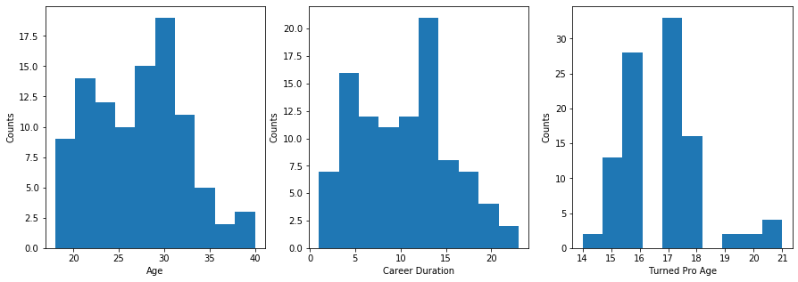

```python
fig, (ax1, ax2, ax3) = plt.subplots(nrows=1, ncols=3,figsize=(15, 5))
ax1.hist(df_career['Age'])
ax1.set_xlabel('Age')
ax1.set_ylabel("Counts")
ax2.hist(df_career['Career Duration'])
ax2.set_xlabel('Career Duration')
ax2.set_ylabel("Counts")
ax3.hist(df_career['Turned Pro Age'])
ax3.set_xlabel('Turned Pro Age')
ax3.set_ylabel("Counts")
plt.show()
```

#### Conclusion: Most of the top 100 Players turned professional between the age of 16-18, their career last mostly for 5-15 years until now(the end of 2019).

### 3. Playing Habbits

##### What are the players' most commonly used playing hand?

```python
df_top100['Plays'].value_counts()
```

```
Right-Handed, Two-Handed Backhand    73
Right-Handed, One-Handed Backhand    13
Left-Handed, Two-Handed Backhand     12
Left-Handed, One-Handed Backhand      2
Name: Plays, dtype: int64
```

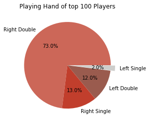

```python
labels = 'Right Double', 'Right Single', 'Left Double', 'Left Single'
sizes = df_top100['Plays'].value_counts().to_list()
explode = (0, 0, 0, 0.1)
colors = ['#CC6758','#C13E2C', '#9A5B4E', '#CECECC']
fig1, ax1 = plt.subplots()
ax1.pie(sizes, explode=explode, labels=labels, startangle=0, colors = colors,autopct='%1.1f%%')
plt.title('Playing Hand of top 100 Players')
plt.show()
```

#### Conclusion: Most players（73%）plays Right-Handed, Two-Handed Backhand; 86% players play right-handed, and 85 out of 100 top players play double back-hand.

### 4. Service statistic

Visualize the serve stats to do direct comparison between palyers.

```python
atp_serve[['avgAcesPerMatch','avgDblFaultsPerMatch']].describe()
```

|  | avgAcesPerMatch | avgDblFaultsPerMatch |
| --- | --- | --- |
| count | 699.000000 | 699.000000 |
| mean | 5.150787 | 3.250644 |
| std | 2.711671 | 1.018502 |
| min | 0.400000 | 1.000000 |
| 25% | 3.300000 | 2.600000 |
| 50% | 4.500000 | 3.100000 |
| 75% | 6.600000 | 3.800000 |
| max | 19.800000 | 7.700000 |

```python
#For 'avgAcesPerMatch', the higher the better; for 'avgDblFaultsPerMatch',the lower the better. Both choose the maximum value as the base.
atp_serve['avgAcesPct'] = atp_serve['avgAcesPerMatch']/19.8*100
atp_serve['avgDblFaultsPerformance']= 100 - atp_serve['avgDblFaultsPerMatch']/7.7*100
atp_serve = atp_serve[['Player','serveRating', '1stServePct','1stServePointsWonPct',
                       '2ndServePointsWonPct', 'serviceGamesWonPct', 'avgAcesPct','avgDblFaultsPerformance','avgAcesPerMatch', 'avgDblFaultsPerMatch']]
atp_serve.head()
```

|  | Player | serveRating | 1stServePct | 1stServePointsWonPct | 2ndServePointsWonPct | serviceGamesWonPct | avgAcesPct | avgDblFaultsPerformance | avgAcesPerMatch | avgDblFaultsPerMatch |
| --- | --- | --- | --- | --- | --- | --- | --- | --- | --- | --- |
| 0 | John Isner | 311.6 | 69.1 | 78.6 | 56.2 | 91.8 | 91.414141 | 71.428571 | 18.1 | 2.2 |
| 1 | Ivo Karlovic | 310.0 | 65.5 | 82.8 | 53.3 | 92.1 | 100.000000 | 54.545455 | 19.8 | 3.5 |
| 2 | Reilly Opelka | 303.0 | 62.0 | 79.7 | 55.2 | 90.4 | 97.474747 | 53.246753 | 19.3 | 3.6 |
| 3 | Milos Raonic | 302.5 | 62.9 | 81.4 | 55.0 | 91.0 | 77.777778 | 58.441558 | 15.4 | 3.2 |
| 4 | Andy Roddick | 299.9 | 64.8 | 79.3 | 56.0 | 90.1 | 59.090909 | 74.025974 | 11.7 | 2.0 |

#### Radar/Spider Chart

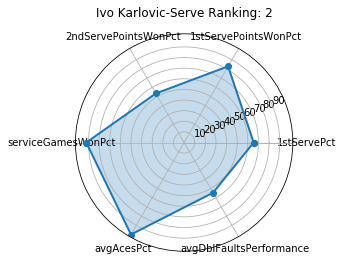

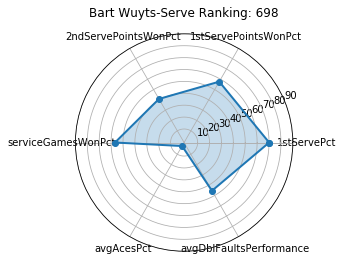

```python
labels = atp_serve.columns[2:-2].to_list()
markers = [10, 20, 30, 40, 50, 60, 70, 80, 90]
str_markers = [str(x) for x in markers]
def service_radar_chart(player_name, attribute_labels = labels, plot_markers = markers, plot_str_markers = str_markers):
    index = atp_serve.loc[atp_serve['Player'] == player_name].index.to_list()[0]
    name = atp_serve.loc[index,'Player']  + '-Serve Ranking: ' + str(index + 1)
    stats = atp_serve.loc[index,'1stServePct':'avgDblFaultsPerformance'].to_list()
    labels = np.array(attribute_labels)
    angles = np.linspace(0, 2 * np.pi, len(labels), endpoint=False)
    stats = np.concatenate((stats,[stats[0]]))
    angles = np.concatenate((angles,[angles[0]]))
    fig= plt.figure()
    ax = fig.add_subplot(111, polar=True)
    ax.plot(angles, stats, 'o-', linewidth=2)
    ax.fill(angles, stats, alpha=0.25)
    ax.set_thetagrids(angles * 180/np.pi, labels)
    plt.yticks(markers)
    ax.set_title(name)
    ax.grid(True)
    return plt.show()
service_radar_chart('Ivo Karlovic')
service_radar_chart('Bart Wuyts')
```

#### Just like other radar charts from computer games, this form can display a player's skill stats intuitively. Players with higher serve rate have a wider spread radar chart as opposed to players with lower serve ratings.

### 5. Histogram about Serving Ratings

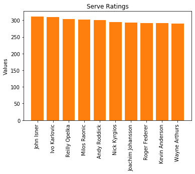

```python
plt.bar(x=atp_serve.head(10).Player, height=atp_serve.head(10).serveRating);
plt.ylabel('Values')
plt.title('Serve Ratings')
plt.xticks(rotation='vertical')
plt.bar(x=atp_serve.head(10).Player, height=atp_serve.head(10).serveRating);
```

## Part 3: Regression Model

#### We wanted to generate a regression model between the technical statistics we scraped and the atp points for players.

As we can see from the correlation matrix showed below, the stats for serve & return tables are internal correlated but other parameters all have rather weak correlation with atp points earned.

We do realize that we are missing a good variable which indicates how many atp games a player played during the past year and to which round he entered. It is important but not easily accessible by directly scraping since this envolves a lot of keyword filtering and is case by case for each player. Yet we could still continue with what we have at hand.

#### We can expect that our model might be successful yet with multicollinearity.

```python
df86 = dftop100_86[['Points','Ranking','Age', 'Turned Pro','Tourn Played','serveRating', '1stServePct',
                    '1stServePointsWonPct','2ndServePointsWonPct', 'serviceGamesWonPct', 'avgAcesPerMatch',
       'avgDblFaultsPerMatch', 'returnRating', '1stServeReturnPointsWonPct',
       '2ndServeReturnPointsWonPct', 'returnGamesWonPct',
       'brkPointsConvertedPct']]
corr1 = df86.corr()
corr1.style.background_gradient(cmap='coolwarm')
```

|  | Points | Age | Turned Pro | Tourn Played | serveRating | 1stServePct | 1stServePointsWonPct | 2ndServePointsWonPct | serviceGamesWonPct | avgAcesPerMatch | avgDblFaultsPerMatch | returnRating | 1stServeReturnPointsWonPct | 2ndServeReturnPointsWonPct | returnGamesWonPct | brkPointsConvertedPct |
| --- | --- | --- | --- | --- | --- | --- | --- | --- | --- | --- | --- | --- | --- | --- | --- | --- |
| Points | 1 | 0.0782837 | -0.151032 | -0.372524 | 0.272482 | 0.184227 | 0.167646 | 0.437868 | 0.320637 | -0.0677146 | -0.180025 | 0.448289 | 0.463463 | 0.39465 | 0.483883 | 0.326951 |
| Age | 0.0782837 | 1 | -0.959726 | -0.302082 | 0.159943 | 0.0391001 | 0.100748 | 0.209096 | 0.144754 | 0.0765938 | -0.204712 | 0.162075 | 0.264916 | 0.0440284 | 0.192111 | 0.104781 |
| Turned Pro | -0.151032 | -0.959726 | 1 | 0.316072 | -0.0933545 | -0.0238801 | -0.030272 | -0.238468 | -0.0926445 | 0.0363846 | 0.227556 | -0.281789 | -0.366779 | -0.165147 | -0.309363 | -0.213325 |
| Tourn Played | -0.372524 | -0.302082 | 0.316072 | 1 | -0.520269 | -0.197362 | -0.38695 | -0.500064 | -0.522636 | -0.31139 | 0.115002 | -0.0216762 | -0.0413368 | -0.017452 | -0.0624024 | 0.0566314 |
| serveRating | 0.272482 | 0.159943 | -0.0933545 | -0.520269 | 1 | 0.329792 | 0.846893 | 0.656393 | 0.97382 | 0.790469 | -0.109732 | -0.512158 | -0.450095 | -0.509597 | -0.487237 | -0.482031 |
| 1stServePct | 0.184227 | 0.0391001 | -0.0238801 | -0.197362 | 0.329792 | 1 | -0.148022 | 0.329554 | 0.173306 | -0.012948 | -0.377287 | -0.000376158 | -0.0637168 | 0.0127974 | 0.0103525 | 0.0239664 |
| 1stServePointsWonPct | 0.167646 | 0.100748 | -0.030272 | -0.38695 | 0.846893 | -0.148022 | 1 | 0.325658 | 0.897091 | 0.868425 | 0.232704 | -0.552328 | -0.41562 | -0.595523 | -0.541969 | -0.509826 |
| 2ndServePointsWonPct | 0.437868 | 0.209096 | -0.238468 | -0.500064 | 0.656393 | 0.329554 | 0.325658 | 1 | 0.660601 | 0.160659 | -0.55115 | -0.0240724 | -0.0961793 | 0.0649173 | 0.011121 | -0.0949893 |
| serviceGamesWonPct | 0.320637 | 0.144754 | -0.0926445 | -0.522636 | 0.97382 | 0.173306 | 0.897091 | 0.660601 | 1 | 0.752828 | -0.0545163 | -0.464396 | -0.391304 | -0.468773 | -0.444537 | -0.440655 |
| avgAcesPerMatch | -0.0677146 | 0.0765938 | 0.0363846 | -0.31139 | 0.790469 | -0.012948 | 0.868425 | 0.160659 | 0.752828 | 1 | 0.340363 | -0.72785 | -0.613261 | -0.757732 | -0.707381 | -0.653005 |
| avgDblFaultsPerMatch | -0.180025 | -0.204712 | 0.227556 | 0.115002 | -0.109732 | -0.377287 | 0.232704 | -0.55115 | -0.0545163 | 0.340363 | 1 | -0.209103 | -0.104091 | -0.300839 | -0.220356 | -0.143442 |
| returnRating | 0.448289 | 0.162075 | -0.281789 | -0.0216762 | -0.512158 | -0.000376158 | -0.552328 | -0.0240724 | -0.464396 | -0.72785 | -0.209103 | 1 | 0.916822 | 0.93165 | 0.990612 | 0.91079 |
| 1stServeReturnPointsWonPct | 0.463463 | 0.264916 | -0.366779 | -0.0413368 | -0.450095 | -0.0637168 | -0.41562 | -0.0961793 | -0.391304 | -0.613261 | -0.104091 | 0.916822 | 1 | 0.769862 | 0.91998 | 0.764433 |
| 2ndServeReturnPointsWonPct | 0.39465 | 0.0440284 | -0.165147 | -0.017452 | -0.509597 | 0.0127974 | -0.595523 | 0.0649173 | -0.468773 | -0.757732 | -0.300839 | 0.93165 | 0.769862 | 1 | 0.924259 | 0.7919 |
| returnGamesWonPct | 0.483883 | 0.192111 | -0.309363 | -0.0624024 | -0.487237 | 0.0103525 | -0.541969 | 0.011121 | -0.444537 | -0.707381 | -0.220356 | 0.990612 | 0.91998 | 0.924259 | 1 | 0.863272 |
| brkPointsConvertedPct | 0.326951 | 0.104781 | -0.213325 | 0.0566314 | -0.482031 | 0.0239664 | -0.509826 | -0.0949893 | -0.440655 | -0.653005 | -0.143442 | 0.91079 | 0.764433 | 0.7919 | 0.863272 | 1 |

```python
# Delete variables unrelated to the regression model. Leave those related judging by experience.
# Delete 'avgAcesPct','avgDblFaultsPerformance' since they are converted from 'avgAcesPerMatch', 'avgDblFaultsPerMatch'.
df_regression = dftop100_86[['Ranking', 'Player Name','Age', 'Points',
       'Tourn Played', 'Points Dropping','Turned Pro','serveRating', '1stServePct', '1stServePointsWonPct',
       '2ndServePointsWonPct', 'serviceGamesWonPct', 'avgAcesPerMatch', 'avgDblFaultsPerMatch',
       'returnRating', '1stServeReturnPointsWonPct',
       '2ndServeReturnPointsWonPct', 'returnGamesWonPct',
       'brkPointsConvertedPct']]
df_regression.dtypes
```

```
Ranking                        object
Player Name                    object
Age                             int32
Points                          int32
Tourn Played                    int32
Points Dropping                 int32
Turned Pro                      int32
serveRating                   float64
1stServePct                   float64
1stServePointsWonPct          float64
2ndServePointsWonPct          float64
serviceGamesWonPct            float64
avgAcesPerMatch               float64
avgDblFaultsPerMatch          float64
returnRating                  float64
1stServeReturnPointsWonPct    float64
2ndServeReturnPointsWonPct    float64
returnGamesWonPct             float64
brkPointsConvertedPct         float64
dtype: object
```

#### Since higher the score, the higher would a player rank, we won't consider rank as an independent variable also.

```python
import statsmodels.api as sm
X = df_regression[['Age', 'Tourn Played', 'Points Dropping','Turned Pro','serveRating', '1stServePct',
                   '1stServePointsWonPct','2ndServePointsWonPct', 'serviceGamesWonPct', 'avgAcesPerMatch',
                   'avgDblFaultsPerMatch', 'returnRating', '1stServeReturnPointsWonPct','2ndServeReturnPointsWonPct',
                   'returnGamesWonPct', 'brkPointsConvertedPct']]
y = df_regression[['Points']]

model = sm.OLS(y, X).fit()
model.summary()
```

OLS Regression Results

| Dep. Variable: | Points | R-squared (uncentered): | 0.827 |
| --- | --- | --- | --- |
| Model: | OLS | Adj. R-squared (uncentered): | 0.797 |
| Method: | Least Squares | F-statistic: | 26.93 |
| Date: | Thu, 12 Dec 2019 | Prob (F-statistic): | 1.10e-22 |
| Time: | 21:16:10 | Log-Likelihood: | -713.29 |
| No. Observations: | 86 | AIC: | 1453. |
| Df Residuals: | 73 | BIC: | 1484. |
| Df Model: | 13 |  |  |
| Covariance Type: | nonrobust |  |  |

|  | coef | std err | t | P>\|t\| | [0.025 | 0.975] |
| --- | --- | --- | --- | --- | --- | --- |
| Age | -82.6747 | 28.518 | -2.899 | 0.005 | -139.511 | -25.839 |
| Tourn Played | 10.6850 | 40.607 | 0.263 | 0.793 | -70.245 | 91.615 |
| Points Dropping | -4.658e-16 | 3.29e-13 | -0.001 | 0.999 | -6.56e-13 | 6.55e-13 |
| Turned Pro | -8.4935 | 7.022 | -1.210 | 0.230 | -22.488 | 5.501 |
| serveRating | 38.3834 | 36.374 | 1.055 | 0.295 | -34.110 | 110.877 |
| 1stServePct | 37.6537 | 67.294 | 0.560 | 0.578 | -96.463 | 171.770 |
| 1stServePointsWonPct | 90.8147 | 214.420 | 0.424 | 0.673 | -336.523 | 518.152 |
| 2ndServePointsWonPct | -29.6761 | 155.563 | -0.191 | 0.849 | -339.712 | 280.360 |
| serviceGamesWonPct | 151.9019 | 228.250 | 0.666 | 0.508 | -303.000 | 606.804 |
| avgAcesPerMatch | -128.6788 | 100.646 | -1.279 | 0.205 | -329.266 | 71.908 |
| avgDblFaultsPerMatch | 83.6321 | 177.258 | 0.472 | 0.638 | -269.642 | 436.906 |
| returnRating | 16.1756 | 30.263 | 0.535 | 0.595 | -44.138 | 76.489 |
| 1stServeReturnPointsWonPct | -102.9931 | 145.428 | -0.708 | 0.481 | -392.830 | 186.844 |
| 2ndServeReturnPointsWonPct | -242.1912 | 123.202 | -1.966 | 0.053 | -487.733 | 3.351 |
| returnGamesWonPct | 553.5813 | 191.492 | 2.891 | 0.005 | 171.938 | 935.225 |
| brkPointsConvertedPct | -192.2214 | 74.470 | -2.581 | 0.012 | -340.639 | -43.803 |

| Omnibus: | 11.054 | Durbin-Watson: | 1.190 |
| --- | --- | --- | --- |
| Prob(Omnibus): | 0.004 | Jarque-Bera (JB): | 11.781 |
| Skew: | 0.726 | Prob(JB): | 0.00277 |
| Kurtosis: | 4.087 | Cond. No. | 4.25e+18 |

Warnings:  
[1] Standard Errors assume that the covariance matrix of the errors is correctly specified.  
[2] The smallest eigenvalue is 1.98e-29. This might indicate that there are  
strong multicollinearity problems or that the design matrix is singular.

### Interpreting the model result

We can see from the table summery that we get a pretty R square in our model-- 0.827, which means the model explains 82.7% of the variance in our dependent variable.

As we expected, we get a warning about multicollinearity problems, which means our independent variables in the model are highly intercorrelated, this might harm our ability to interpret the model.

## Part 4: Another Dataset, Another perspective

### A. Field Exploring

```python
df2 = pd.read_html('https://github.com/fivethirtyeight/data/blob/master/tennis-time/events_time.csv')
df_seconds_added_per_point = df2[0]
df_seconds_added_per_point=df_seconds_added_per_point.drop('years',axis=1)
df_1 = pd.read_html('https://github.com/fivethirtyeight/data/blob/master/tennis-time/players_time.csv')
df_player_adding_seconds = df_1[0]
df_player_adding_seconds.head()
```

|  | Unnamed: 0 | player | seconds_added_per_point |
| --- | --- | --- | --- |
| 0 | NaN | Dustin Brown | -6.37 |
| 1 | NaN | Rohan Bopanna | -4.95 |
| 2 | NaN | Chris Guccione | -4.63 |
| 3 | NaN | Benoit Paire | -4.56 |
| 4 | NaN | Lukas Dlouhy | -4.35 |

```python
df_seconds_added_per_point['surface'].unique()
```

```
array(['Grass', 'Carpet', 'Hard', 'Clay'], dtype=object)
```

There are 4 unique surfaces as shown above. We will consider them in our further analysis.

```python
grouped = df_seconds_added_per_point.groupby(by=df_seconds_added_per_point['surface'])
grouped.head()
```

|  | Unnamed: 0 | tournament | surface | seconds_added_per_point |
| --- | --- | --- | --- | --- |
| 0 | NaN | Wimbledon | Grass | -2.98 |
| 1 | NaN | London Olympics | Grass | -2.62 |
| 2 | NaN | Manchester | Grass | -2.33 |
| 3 | NaN | Eastbourne | Grass | -1.78 |
| 4 | NaN | Birmingham | Carpet | -1.63 |
| 5 | NaN | Queen's Club | Grass | -1.50 |
| 6 | NaN | Lyon | Hard | -1.35 |
| 7 | NaN | Las Vegas | Hard | -1.32 |
| 8 | NaN | Stockholm Masters | Carpet | -0.90 |
| 10 | NaN | Orlando | Hard | -0.68 |
| 11 | NaN | Tokyo Indoor | Carpet | -0.64 |
| 13 | NaN | Bogota | Clay | -0.57 |
| 15 | NaN | Beijing | Carpet | -0.54 |
| 16 | NaN | Brussels | Carpet | -0.53 |
| 18 | NaN | Wellington | Hard | -0.44 |
| 20 | NaN | US Open | Hard | -0.17 |
| 35 | NaN | Gstaad | Clay | 0.44 |
| 53 | NaN | Roland Garros | Clay | 0.79 |
| 73 | NaN | Mexico City | Clay | 1.15 |
| 103 | NaN | Stuttgart | Clay | 1.65 |

```python
df_grass = grouped.get_group('Grass')
df_grass.head()
```

|  | Unnamed: 0 | tournament | surface | seconds_added_per_point |
| --- | --- | --- | --- | --- |
| 0 | NaN | Wimbledon | Grass | -2.98 |
| 1 | NaN | London Olympics | Grass | -2.62 |
| 2 | NaN | Manchester | Grass | -2.33 |
| 3 | NaN | Eastbourne | Grass | -1.78 |
| 5 | NaN | Queen's Club | Grass | -1.50 |

```python
df_grass_list = []
df_grass_list = df_grass.seconds_added_per_point.mean()
df_grass_list
```

```
-1.3329999999999997
```

It is observed that Players quicken the pace of the game on the Grass surface with every additional point. This comes down to the physical factors like Dew factor, Softening of the pitch over time,etc.

```python
df_carpet_list = []
df_carpet = grouped.get_group('Carpet')
df_carpet.head()
```

|  | Unnamed: 0 | tournament | surface | seconds_added_per_point |
| --- | --- | --- | --- | --- |
| 4 | NaN | Birmingham | Carpet | -1.63 |
| 8 | NaN | Stockholm Masters | Carpet | -0.90 |
| 11 | NaN | Tokyo Indoor | Carpet | -0.64 |
| 15 | NaN | Beijing | Carpet | -0.54 |
| 16 | NaN | Brussels | Carpet | -0.53 |

```python
df_carpet_list = df_carpet.seconds_added_per_point.mean()
df_carpet_list
```

```
0.7728947368421053
```

The above value depicts the time taken for seconds added on the Carpet surface

```python
df_hard_list = []
df_hard = grouped.get_group('Hard')
df_hard.head()
```

|  | Unnamed: 0 | tournament | surface | seconds_added_per_point |
| --- | --- | --- | --- | --- |
| 6 | NaN | Lyon | Hard | -1.35 |
| 7 | NaN | Las Vegas | Hard | -1.32 |
| 10 | NaN | Orlando | Hard | -0.68 |
| 18 | NaN | Wellington | Hard | -0.44 |
| 20 | NaN | US Open | Hard | -0.17 |

```python
df_hard_list = df_hard.seconds_added_per_point.mean()
df_hard_list
```

```
1.424767441860465
```

The above value depicts the time taken for seconds added on the Hard surface

```python
df_clay_list = []
df_clay = grouped.get_group('Clay')
df_clay.head()
```

|  | Unnamed: 0 | tournament | surface | seconds_added_per_point |
| --- | --- | --- | --- | --- |
| 13 | NaN | Bogota | Clay | -0.57 |
| 35 | NaN | Gstaad | Clay | 0.44 |
| 53 | NaN | Roland Garros | Clay | 0.79 |
| 73 | NaN | Mexico City | Clay | 1.15 |
| 103 | NaN | Stuttgart | Clay | 1.65 |

```python
df_clay_list = df_clay.seconds_added_per_point.mean()
df_clay_list
```

```
3.1352112676056345
```

```python
x = range(4)
data = {'Carpet':df_carpet_list,'Hard':df_hard_list,'Clay':df_clay_list,'Grass':df_grass_list}
df_data_avg_time = pd.DataFrame.from_dict(data, orient='index',columns=['seconds_added_per_point'])
df_data_avg_time
```

|  | seconds_added_per_point |
| --- | --- |
| Carpet | 0.772895 |
| Hard | 1.424767 |
| Clay | 3.135211 |
| Grass | -1.333000 |

```
<BarContainer object of 4 artists>
```

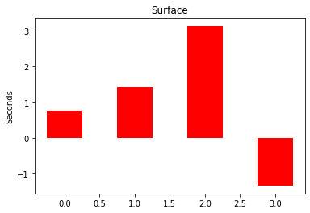

```python
fig = plt.figure()
ax = plt.subplot(111)
plt.ylabel('Seconds')
plt.title('Surface')
ax.bar(x, df_data_avg_time.seconds_added_per_point, width=0.5, color='r')
```

Above Bars depict 'Carpet Court', 'Hard Court', 'Clay Court' and 'Grass Court' respectively.

#### The above bar graph depicts the seconds taken by the players for winning each additional point. We can see that only on Grass Court, players take lesser time to gain the next point while on other courts they tend to take their time. This is crucial because each additional second keeps on piling up to potentially push the game over to a second day which may cause one of the players to play 2 different matches back to back without a break

```python
df_player_adding_seconds = df_player_adding_seconds.sort_values('seconds_added_per_point',ascending=False)
df_player_adding_seconds.head(50)
```

|  | Unnamed: 0 | player | seconds_added_per_point |
| --- | --- | --- | --- |
| 217 | NaN | Emanuel Couto | 6.35 |
| 216 | NaN | Nicolas Massu | 6.21 |
| 215 | NaN | Rafael Nadal | 5.92 |
| 214 | NaN | Martin Stringari | 5.68 |
| 213 | NaN | T.J. Middleton | 5.60 |
| 212 | NaN | Lucas Arnold Ker | 5.35 |
| 211 | NaN | John McEnroe | 5.22 |
| 210 | NaN | Julian Knowle | 5.15 |
| 209 | NaN | Joao Cunha Silva | 5.10 |
| 208 | NaN | Michael Chang | 4.94 |
| 207 | NaN | Andrei Cherkasov | 4.92 |
| 206 | NaN | Jimmy Connors | 4.90 |
| 205 | NaN | Hernan Gumy | 4.86 |
| 204 | NaN | Thomas Hogstedt | 4.77 |
| 203 | NaN | Alex Corretja | 4.64 |
| 202 | NaN | Jim Courier | 4.51 |
| 201 | NaN | Ivan Lendl | 4.35 |
| 200 | NaN | Roberto Jabali | 4.35 |
| 199 | NaN | Jan Frode Andersen | 4.12 |
| 198 | NaN | Carlos Berlocq | 4.08 |
| 197 | NaN | Thierry Guardiola | 3.97 |
| 196 | NaN | Gilbert Schaller | 3.93 |
| 195 | NaN | Marcos Ondruska | 3.93 |
| 194 | NaN | Jean Philippe Fleurian | 3.92 |
| 193 | NaN | Shuzo Matsuoka | 3.90 |
| 192 | NaN | Attila Savolt | 3.81 |
| 191 | NaN | Markus Hantschk | 3.77 |
| 190 | NaN | Pat Cash | 3.73 |
| 189 | NaN | Nicolas Lapentti | 3.72 |
| 188 | NaN | Martin Vassallo Arguello | 3.69 |
| 187 | NaN | Marc Lopez | 3.67 |
| 186 | NaN | Martin Jaite | 3.63 |
| 185 | NaN | Boris Becker | 3.55 |
| 184 | NaN | Christo Van Rensburg | 3.55 |
| 183 | NaN | Nicolas Kiefer | 3.51 |
| 182 | NaN | Illya Marchenko | 3.40 |
| 181 | NaN | Renzo Furlan | 3.37 |
| 180 | NaN | Lionel Roux | 3.36 |
| 179 | NaN | Justin Gimelstob | 3.32 |
| 178 | NaN | Guillermo Canas | 3.31 |
| 177 | NaN | Jordi Arrese | 3.30 |
| 176 | NaN | Mats Wilander | 3.30 |
| 175 | NaN | Jim Grabb | 3.27 |
| 174 | NaN | Pablo Arraya | 3.26 |
| 173 | NaN | Juan Martin Del Potro | 3.23 |
| 172 | NaN | Lleyton Hewitt | 3.22 |
| 171 | NaN | Borna Coric | 3.18 |
| 170 | NaN | Bart Wuyts | 3.16 |
| 169 | NaN | Markus Naewie | 3.13 |
| 168 | NaN | Arnaud Clement | 3.11 |

#### Above are the top 50 players that take most time in earning their next point which in turn means they take their time to serve or get ready receive a serve. This technique is used for various things like: Breaking the concentration of the opposition, Creating mental pressure, Gaining some rest, Delaying the game and taking it into the next day, etc.

### B. Indivisual Player Exploring

```python
df_matches_2019 = pd.read_csv(r'C:\Users\alicia\Downloads\Homework\X-Prj\tennis_atp-master\atp_matches_2019.csv')
df_matches_2019.head()
```

|  | tourney_id | tourney_name | surface | draw_size | tourney_level | tourney_date | match_num | winner_id | winner_seed | winner_entry | ... | w_bpFaced | l_ace | l_df | l_svpt | l_1stIn | l_1stWon | l_2ndWon | l_SvGms | l_bpSaved | l_bpFaced |
| --- | --- | --- | --- | --- | --- | --- | --- | --- | --- | --- | --- | --- | --- | --- | --- | --- | --- | --- | --- | --- | --- |
| 0 | 2019-M020 | Brisbane | Hard | 32 | A | 20181231 | 300 | 105453 | 2 | NaN | ... | 6.0 | 8.0 | 6.0 | 100.0 | 54.0 | 34.0 | 20.0 | 14.0 | 10.0 | 15.0 |
| 1 | 2019-M020 | Brisbane | Hard | 32 | A | 20181231 | 299 | 106421 | 4 | NaN | ... | 1.0 | 17.0 | 2.0 | 77.0 | 52.0 | 36.0 | 7.0 | 10.0 | 10.0 | 13.0 |
| 2 | 2019-M020 | Brisbane | Hard | 32 | A | 20181231 | 298 | 105453 | 2 | NaN | ... | 2.0 | 10.0 | 3.0 | 46.0 | 27.0 | 15.0 | 6.0 | 8.0 | 1.0 | 5.0 |
| 3 | 2019-M020 | Brisbane | Hard | 32 | A | 20181231 | 297 | 104542 | NaN | PR | ... | 5.0 | 1.0 | 2.0 | 81.0 | 60.0 | 38.0 | 9.0 | 11.0 | 4.0 | 6.0 |
| 4 | 2019-M020 | Brisbane | Hard | 32 | A | 20181231 | 296 | 106421 | 4 | NaN | ... | 8.0 | 29.0 | 5.0 | 94.0 | 56.0 | 46.0 | 19.0 | 15.0 | 2.0 | 4.0 |

5 rows × 49 columns

```python
df_ages_w_l = df_matches_2019[['winner_age','loser_age']]
df_ages_w_l
```

|  | winner_age | loser_age |
| --- | --- | --- |
| 0 | 29.004791 | 22.885695 |
| 1 | 22.885695 | 33.705681 |
| 2 | 29.004791 | 31.882272 |
| 3 | 33.705681 | 19.868583 |
| 4 | 22.885695 | 28.010951 |
| ... | ... | ... |
| 2776 | 22.688569 | 22.595483 |
| 2777 | 22.688569 | 26.828200 |
| 2778 | 31.170431 | 22.800821 |
| 2779 | 22.611910 | 20.386037 |
| 2780 | 29.971253 | 22.800821 |

2781 rows × 2 columns

```python
df_ages_w_l['Difference']= df_ages_w_l['winner_age'] - df_ages_w_l['loser_age']
df_ages_w_l['Difference'].mean()
```

```
0.1262012271068727
```

```python
df_winner_name = df_matches_2019.loc[df_matches_2019['winner_name'] == 'Rafael Nadal']
df_nadal_w = df_winner_name[['winner_name','w_ace','w_1stWon','w_2ndWon','winner_hand','loser_hand','minutes']]
df_nadal_w = df_nadal_w.fillna(0)
df_nadal_w.head()
```

|  | winner_name | w_ace | w_1stWon | w_2ndWon | winner_hand | loser_hand | minutes |
| --- | --- | --- | --- | --- | --- | --- | --- |
| 202 | Rafael Nadal | 6.0 | 40.0 | 16.0 | L | R | 135.0 |
| 234 | Rafael Nadal | 6.0 | 43.0 | 16.0 | L | R | 116.0 |
| 250 | Rafael Nadal | 6.0 | 53.0 | 8.0 | L | R | 142.0 |
| 258 | Rafael Nadal | 5.0 | 45.0 | 16.0 | L | R | 125.0 |
| 262 | Rafael Nadal | 11.0 | 48.0 | 12.0 | L | R | 107.0 |

```python
df_loser_name = df_matches_2019.loc[df_matches_2019['loser_name'] == 'Rafael Nadal']
df_nadal_l = df_loser_name[['loser_name','l_ace','l_1stWon','l_2ndWon','loser_hand','winner_hand','minutes']]
df_nadal_l = df_nadal_l.fillna(0)
df_nadal_l.head()
```

|  | loser_name | l_ace | l_1stWon | l_2ndWon | loser_hand | winner_hand | minutes |
| --- | --- | --- | --- | --- | --- | --- | --- |
| 265 | Rafael Nadal | 3.0 | 24.0 | 16.0 | L | R | 124.0 |
| 528 | Rafael Nadal | 8.0 | 54.0 | 26.0 | L | R | 183.0 |
| 612 | Rafael Nadal | 0.0 | 0.0 | 0.0 | L | R | 0.0 |
| 860 | Rafael Nadal | 0.0 | 18.0 | 7.0 | L | R | 96.0 |
| 914 | Rafael Nadal | 1.0 | 38.0 | 9.0 | L | R | 124.0 |

```python
mean_won_time = df_nadal_w.minutes.mean()
mean_lost_time = df_nadal_l.minutes.mean()
mean_first_game_won = df_nadal_w.w_1stWon.mean()
mean_first_game_lost = df_nadal_l.l_1stWon.mean()
mean_second_game_won = df_nadal_w.w_2ndWon.mean()
mean_second_game_lost = df_nadal_l.l_2ndWon.mean()
mean_aces_game_won = df_nadal_w.w_ace.mean()
mean_aces_game_lost = df_nadal_l.l_ace.mean()
```

```python
print(mean_won_time)
print(mean_lost_time)
```

```
114.89830508474576
105.22222222222223
```

Rafael Nadal on an average has taken his time whenever he has won a match in 2019

```python
print(mean_aces_game_won)
print(mean_aces_game_lost)
```

```
4.779661016949152
3.111111111111111
```

#### Turns out Aces are a very important part of the Current No.1 Rafael Nadal's arsenal. He has scored 1.6 significantly more aces when he has won the matches as compared to when he has lost the matches in 2019.

```python
df_matches_2016 = pd.read_csv(r'C:\Users\alicia\Downloads\Homework\X-Prj\tennis_atp-master/atp_matches_2016.csv')
```

#### Now let us compare Nadal's poor 2016 season, when he fell to 9th position by the end of the year, with his in form 2019 season where he is ranked no.1 in the world right now and see what has changed.

```python
df_winner_name2 = df_matches_2016.loc[df_matches_2016['winner_name'] == 'Rafael Nadal']
df_nadal_w2 = df_winner_name2[['winner_name','w_ace','w_1stWon','w_2ndWon','winner_hand','loser_hand','minutes']]
df_nadal_w2 = df_nadal_w2.fillna(0)
df_loser_name2 = df_matches_2016.loc[df_matches_2016['loser_name'] == 'Rafael Nadal']
df_nadal_l2 = df_loser_name2[['loser_name','l_ace','l_1stWon','l_2ndWon','loser_hand','winner_hand','minutes']]
df_nadal_l2 = df_nadal_l2.fillna(0)
```

```python
mean_won_time2 = df_nadal_w2.minutes.mean()
mean_lost_time2 = df_nadal_l2.minutes.mean()
mean_first_game_won2 = df_nadal_w2.w_1stWon.mean()
mean_first_game_lost2 = df_nadal_l2.l_1stWon.mean()
mean_second_game_won2 = df_nadal_w2.w_2ndWon.mean()
mean_second_game_lost2 = df_nadal_l2.l_2ndWon.mean()
mean_aces_game_won2 = df_nadal_w2.w_ace.mean()
mean_aces_game_lost2 = df_nadal_l2.l_ace.mean()
```

```python
print(mean_won_time2)
print(mean_lost_time2)
```

```
103.225
135.8
```

Nadal tends to win games at lightning speeds as seen from the data above. That is not at all surprising given the aggressive nature of his game play.

```python
minutes_df = pd.read_csv(r'C:\Users\alicia\Downloads\Homework\X-Prj/game_minutes.csv')
minutes_df
```

|  | Year | Type | Minutes |
| --- | --- | --- | --- |
| 0 | 2016 | Winning Game Minutes | 103.225000 |
| 1 | 2016 | Losing Game Minutes | 135.800000 |
| 2 | 2019 | Winning Game Minutes | 114.898305 |
| 3 | 2019 | Losing Game Minutes | 105.222222 |

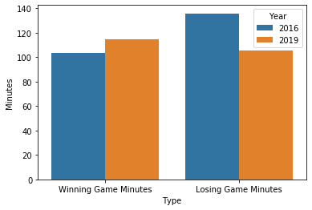

```python
sns.barplot(x=minutes_df.Type, y=minutes_df.Minutes, hue=minutes_df.Year);
```

#### As compared to 2016, the minutes Nadal has played for in 2019 in winning games has risen from which we can infer that he is taking his time during games and hence playing with more concentration.

```python
aces_scored_df = pd.read_csv(r'C:\Users\alicia\Downloads\Homework\X-Prj/aces.csv')
aces_scored_df
```

|  | Year | Type | Count |
| --- | --- | --- | --- |
| 0 | 2016 | Aces in victory | 2.100000 |
| 1 | 2016 | Aces in loss | 2.133333 |
| 2 | 2019 | Aces in victory | 4.779661 |
| 3 | 2019 | Aces in loss | 3.111111 |

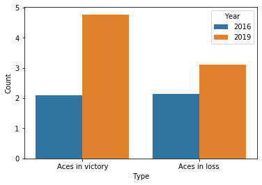

```python
sns.barplot(x=aces_scored_df.Type, y=aces_scored_df.Count, hue=aces_scored_df.Year);
```

#### Through the above graph we can see that Nadal's ace count was poor in 2016 when he fell down to 9th position as compared to 2019 where he is at the top. He had to face a few injuries during 2016 and that had affected his Ace count as Aces require lot of power. Aces turn out to be a very important aspect of his game as seen here. His Ace count becomes more than twice in 2019 which in turn might have been a factor in Nadal winning more matches and finishing 1st.